# 2003 Terrorist Alliances: A Network Analysis Using ERGMS

Zachary Fesen

12/22/2021

**Theoretical Framework**

This analysis examines the dyadic and structural determinants of alliance ties among terrorist organizations. In particular, does homophily exist in the network with respect to ideological Islamic affiliation, state sponsorship, and ideological ethnic affiliation of a terrorist organization? Furthermore, what are the structural configurations of terrorist alliance groupings?

*Structure-Related Hypotheses:*

*H1: Terrorist alliance groupings usually occur with more than two organizations as common alliance members increase the odds of a tie.

*H2: Terrorist alliance groupings are likely to exhibit scale-free network structures.

*Attribute Related Hypotheses:*

*H3: Terrorist Organizations with Islamic ideological foundations tend to form alliances with other Islamically inspired terrorist organizations.* H4: State-Sponsored terrorist organizations are more likely to ally with other state-sponsored terrorist organizations. *H5: Terrorists with control of territory are not more likely to ally with other terrorist organizations with territorial control.

**Data**

This analysis builds on work by [Asal et. al](https://www.tandfonline.com/doi/full/10.1080/10967494.2015.1027431) (2015) who used ERGMS to examine the alliance ties of 395 terrorist organizations with observations between the years 1998 and 2005. However, the present analysis specifically looks alliance ties between terrorist organizations in 2003. The undirected and unweighted network consists of 42 terrorist organizations and is a discrete-time dataset. The data for this project come from the National Consortium for the Study of Terrorism and Responses to Terrorism’s (START) Big Allied and Dangerous [global network](https://www.start.umd.edu/baad/network/2003) of terrorist organizations and corresponding [dataset](https://www.start.umd.edu/data-tools/big-allied-and-dangerous-baad-database-1-lethality-data-1998-2005).

*Nodal attributes (based on 2003 data) include: +territorial control (binary, “TerrStrong”) +state sponsorship (binary, “Statspond”) +ideological Islamic affiliation (binary, “Islam”) +ideological ethnic affiliation (binary, “ContainsEthno”) +Deaths caused by the terrorist organization (Polychotomous, “Deaths”)

The figure below shows the terrorist organizations from 2003 that are included in the network while also coloring red the organizations which have an Islamic Ideological affiliation. Notably, Al-Qaeda appears to have a high degree centrality and is at the center of a cluster of islamically affiliated groups.

*Islamic Affiliation*

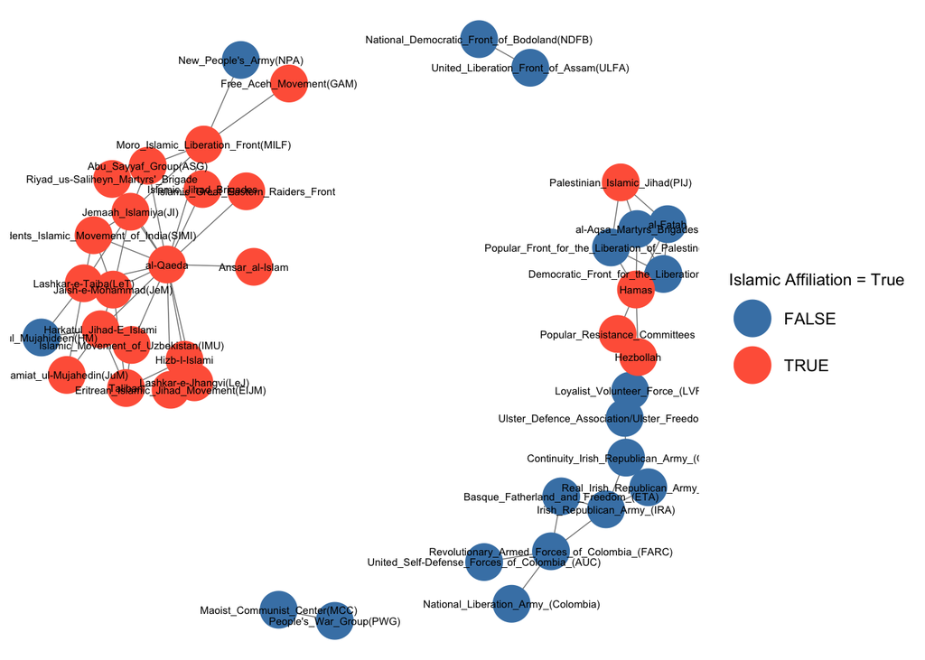

**Modeling Technique and Specification**

As this analysis is interested in examining the organization of alliance ties based on network attributes rather than looking at the actions of network actors I use an Exponential-Family Random Graph Model (ERGM) to examine both the structural and nodal attribute factors of the network. Regarding structural parameters, the network specifies preferential attachment (gwdegree) and clustering (gwesp). The decay parameter for both gwdegree and gwesp is set to 0.25. I use the “nodematch” function to look for homophily with regards to ideological Islamic affiliation, state sponsorship, and ideological ethnic affiliation. Moreover, I use the nodefactor function to take into account that the proportion of ties of vertices may vary based on a given nodal attribute.

Statistical models

|  | Model 1 |
| --- | --- |
| edges | -5.68*** |
|  | (0.05) |
| gwdeg.fixed.0.25 | 1.93*** |
|  | (0.03) |
| gwesp.fixed.0.25 | 0.95*** |
|  | (0.19) |
| nodematch.islam | 1.39*** |
|  | (0.07) |
| nodefactor.islam.1 | 0.06 |
|  | (0.17) |
| nodematch.TerrStrong | 0.36 |
|  | (0.24) |
| nodefactor.TerrStrong.1 | 0.09 |
|  | (0.19) |
| nodematch.Statspond | 0.58** |
|  | (0.23) |
| nodefactor.Statspond.1 | 0.08 |
|  | (0.19) |
| nodematch.ContainEthno | -0.04 |
|  | (0.12) |
| nodefactor.ContainEthno.1 | -0.06 |
|  | (0.19) |
| nodecov.Deaths | 0.00** |
|  | (0.00) |
| AIC | 388.53 |
| BIC | 445.62 |
| Log Likelihood | -182.26 |

p < 0.001; p < 0.01; p < 0.05

**Interpretation**

*Structural Related Hypotheses*

Hypotheses one was confirmed as the geometrically edgewise shared partner measure is positive and statistically significant at the α < 0.001 level and indicates the presence of significant clustering in the network. Therefore, 2003 terrorist alliance groupings are likely to occur in at least triads while the probability of an alliance forming between two terrorist organizations increases with the number of common ties between the two organizations.

The model also confirms Hypotheses two as gwdegree which indicates a preferential attachment is positive and is also statistically significant at the α < 0.001 level. Thus, more popular terrorist organizations have a greater likelihood of forming alliance connections with other terrorist organizations.

*Attribute Related Hypotheses*

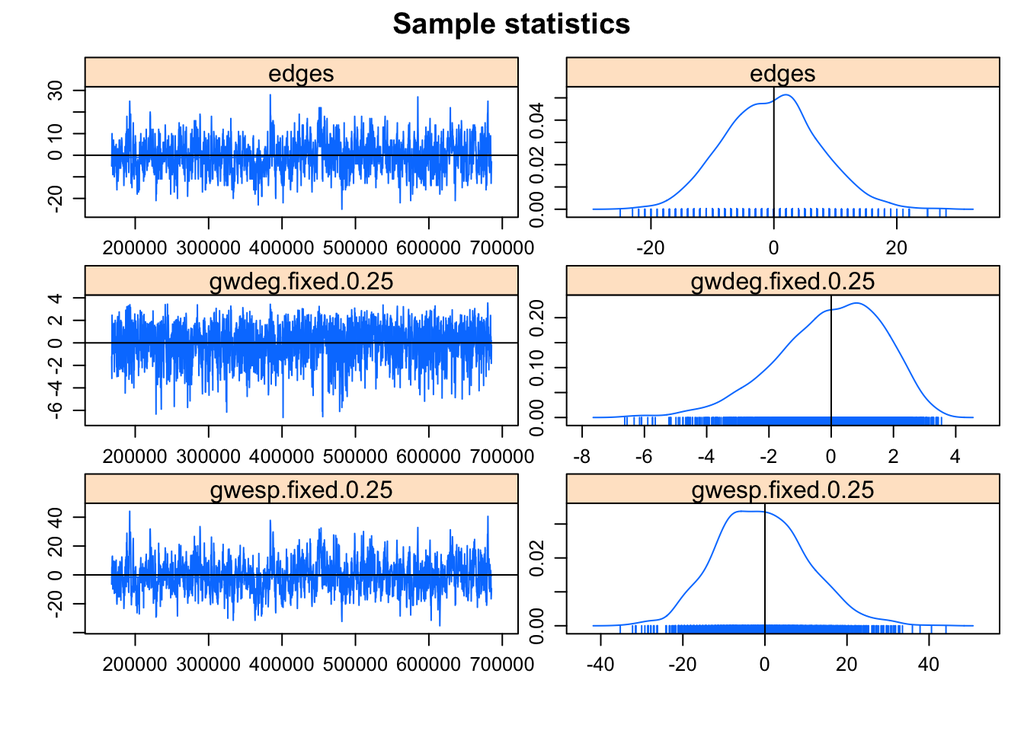

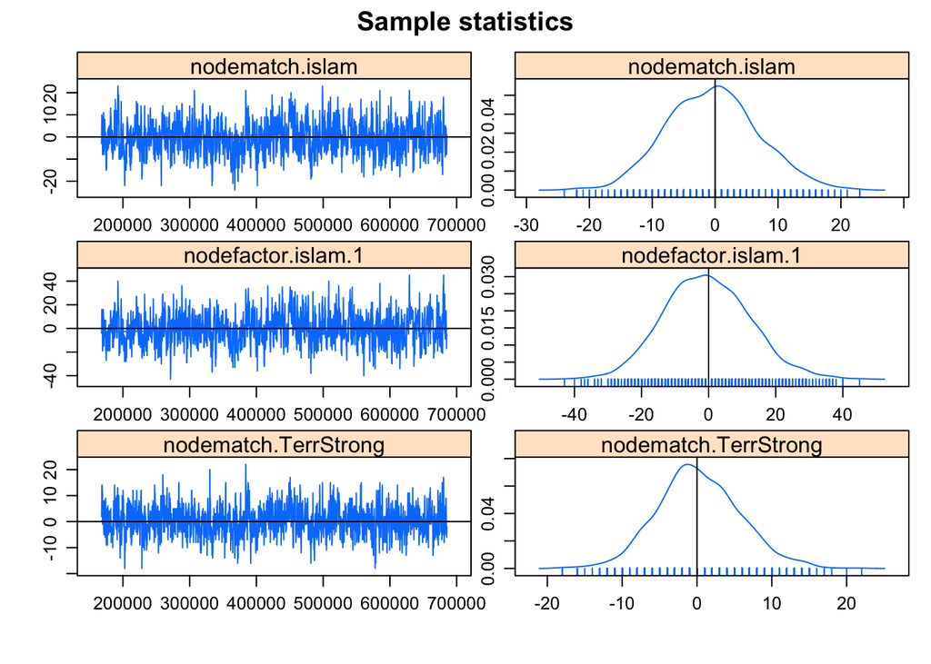

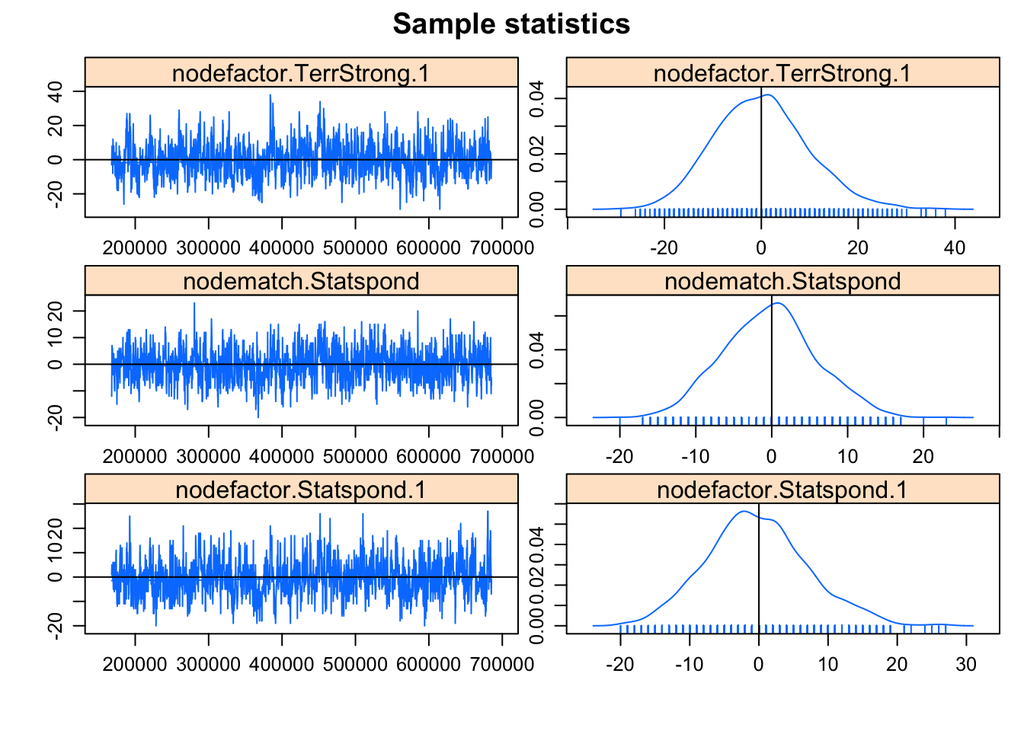

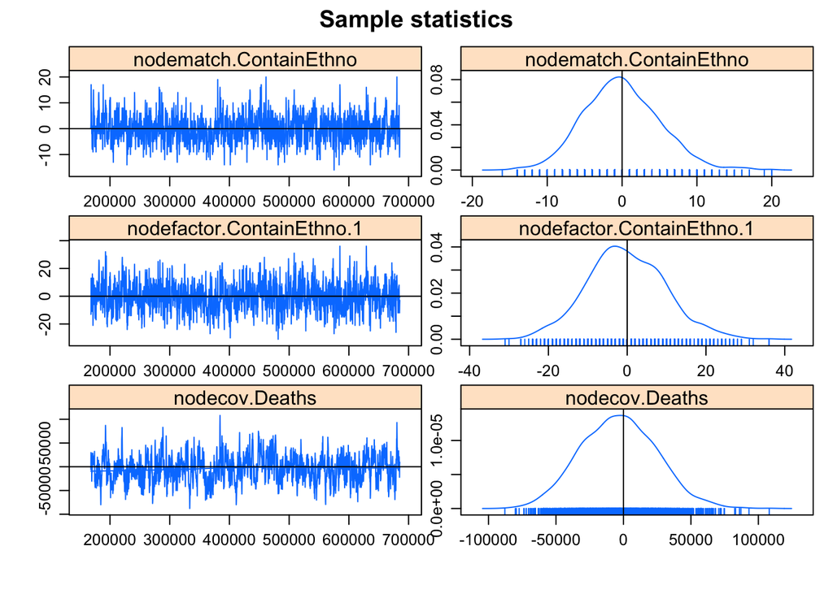

[output not shown]

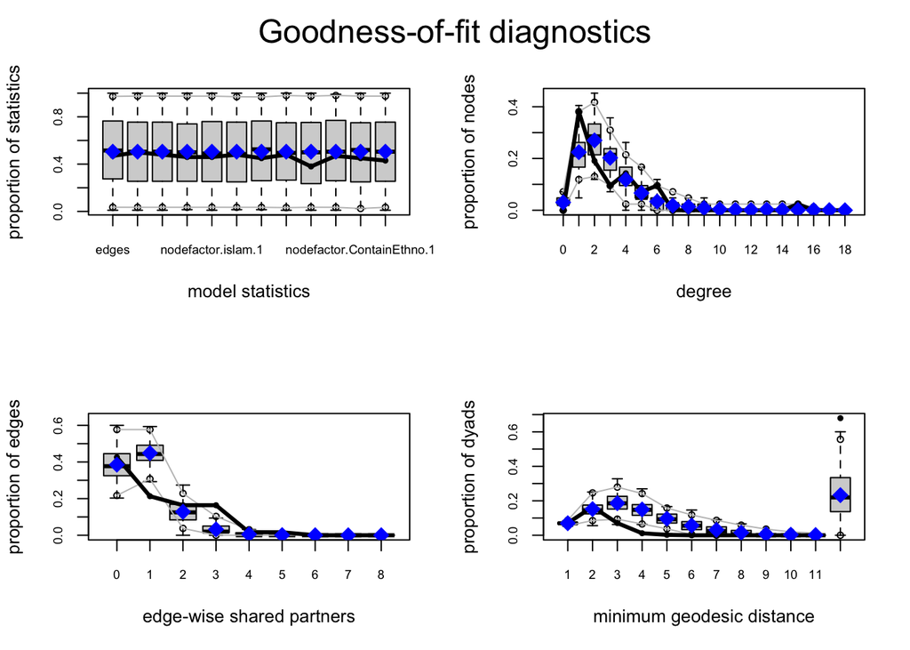

**Markov Chain Monte Carlo Results**

After examining the MCMC diagnostics it appears that the ERGM model has sufficiently converged. Indeed the simulated sample statistics appear to vary randomly around the observed statistics from the BAAD dataset. Moreover, the sample statistics have a smooth bell curve distribution and do not show saw-tooth patterns.

**Goodness of Fit Results**

While the ERGM successfully converges, the goodness of fit casts doubt onto the validity of the modeled network. While the observed statistics fall within the range of simulated values regarding model statistics, the simulated values appear to overestimate the proportion of nodes that are connected by larger numbers of ties. Moreover, the simulated networks overestimate the proportion of nodes with two and three degrees while also overestimating the proportion of nodes with one edge-wise shared partner.

**Limitations and Conclusions**

Overall, the ERGM model of the BAAD Network of 2003 terrorist organization alliance ties shows evidence, clustering, preferential attachment, and homophily based on Islamic ideological affiliation state sponsorship. However, the model does not account for the region of each organization which could further explain the formation of alliance ties. Additionally, further specification of Islamic ideological affiliation by sect could deepen our understanding of cross-sect pacts among Islamic terrorist groups.

**Bibliography**

Asal, V. H., Park, H. H., Rethemeyer, R. K., & Ackerman, G. (2015). With friends like these … why terrorist organizations ally. *International Public Management Journal, 19*(1), 1–30. https://doi.org/10.1080/10967494.2015.1027431

Asal, V. H., Rethemeyer R. K., & Anderson, I. (2011). “BAAD_1_Lethality_Codebook.pdf”, *Big Allied and Dangerous (BAAD) Database 1 - Lethality Data, 1998-2005*, https://doi.org/10.7910/DVN/GPEUFH/OZ41RW, Harvard Dataverse, V3

*Baad Global Network*. National Consortium for the Study of Terrorism and Responses to Terrorism (START). (n.d.). Retrieved from https://www.start.umd.edu/baad/network/2003